# Project: Investigate a Dataset - [Medical Appointment No Shows]

- Introduction
- Data Wrangling
- Exploratory Data Analysis
- Conclusions

## Introduction

### Dataset Description

> A person makes a doctor appointment, receives all the instructions and no-show. Who to blame?

#### Content

> 110.527 medical appointments and its 14 associated variables (characteristics). The most important one if the patient show-up or no-show to the appointment. Variable names are self-explanatory.

#### Data Dictionary

> **1 - PatientId**

> Identification of a patient.

> **2 - AppointmentID**

> Identification of each appointment.

> **3 - Gender**

> Male or Female . Female is the greater proportion, woman takes way more care of they health in comparison to man.

> **4 - ScheduledDay**

> The day of the actuall appointment, when they have to visit the doctor.

> **5 - AppointmentDay**

> The day someone called or registered the appointment, this is before appointment of course.

> **6 - Age**

> How old is the patient.

> **7 - Neighbourhood**

> Where the appointment takes place.

> **8 - Scholarship**

> Indicates whether or not the patient is enrolled in Brasilian welfare program Bolsa Família.

> **9 - Hipertension**

> True or False.

> **10 - Diabetes**

> True or False.

> **11 - Alcoholism**

> True or False.

> **12 - Handcap**

> True or False.

> **13 - SMS_received**

> 1 or more messages sent to the patient.

> **14 - No-show**

> Yes or No.

### Question(s) for Analysis

> **Why do patients miss their scheduled appointments?** **What variable(s) might affect the propabelity of them showing-up for their scheduled appointment?**

```python
# import statements for all of the packages in use.

import pandas as pd
import numpy as np
import matplotlib.pyplot as plt
import seaborn as sns

%matplotlib inline
sns.set_theme(context='paper', style="darkgrid")
```

## Data Wrangling

> In this section of the report, we will load in the data, check for cleanliness, and then trim and clean your dataset for analysis.

### Assessing Data

> We will start by loading in our data set **noshowappointments-kagglev2-may-2016.csv**.

> And then we will perform a general inspection to see what obstacles might oppose us.

```python
# Loading our data and printing out a few lines. Performing operations to inspect data
#   types and look for instances of missing or possibly errant data.
df = pd.read_csv('noshowappointments-kagglev2-may-2016.csv')
```

```python
df.head()
```

|  | PatientId | AppointmentID | Gender | ScheduledDay | AppointmentDay | Age | Neighbourhood | Scholarship | Hipertension | Diabetes | Alcoholism | Handcap | SMS_received | No-show |
| --- | --- | --- | --- | --- | --- | --- | --- | --- | --- | --- | --- | --- | --- | --- |
| 0 | 2.987250e+13 | 5642903 | F | 2016-04-29T18:38:08Z | 2016-04-29T00:00:00Z | 62 | JARDIM DA PENHA | 0 | 1 | 0 | 0 | 0 | 0 | No |
| 1 | 5.589978e+14 | 5642503 | M | 2016-04-29T16:08:27Z | 2016-04-29T00:00:00Z | 56 | JARDIM DA PENHA | 0 | 0 | 0 | 0 | 0 | 0 | No |
| 2 | 4.262962e+12 | 5642549 | F | 2016-04-29T16:19:04Z | 2016-04-29T00:00:00Z | 62 | MATA DA PRAIA | 0 | 0 | 0 | 0 | 0 | 0 | No |
| 3 | 8.679512e+11 | 5642828 | F | 2016-04-29T17:29:31Z | 2016-04-29T00:00:00Z | 8 | PONTAL DE CAMBURI | 0 | 0 | 0 | 0 | 0 | 0 | No |
| 4 | 8.841186e+12 | 5642494 | F | 2016-04-29T16:07:23Z | 2016-04-29T00:00:00Z | 56 | JARDIM DA PENHA | 0 | 1 | 1 | 0 | 0 | 0 | No |

```python
# exploring the shape of the data
df.shape
```

```
(110527, 14)
```

The Dataframe consistes of 14 columns, and has 110527 entries.

Checking for missing values ,undescriptive column names and inappropriate data types...

```python
df.info()
```

```
<class 'pandas.core.frame.DataFrame'>
RangeIndex: 110527 entries, 0 to 110526
Data columns (total 14 columns):
 #   Column          Non-Null Count   Dtype
---  ------          --------------   -----
 0   PatientId       110527 non-null  float64
 1   AppointmentID   110527 non-null  int64
 2   Gender          110527 non-null  object
 3   ScheduledDay    110527 non-null  object
 4   AppointmentDay  110527 non-null  object
 5   Age             110527 non-null  int64
 6   Neighbourhood   110527 non-null  object
 7   Scholarship     110527 non-null  int64
 8   Hipertension    110527 non-null  int64
 9   Diabetes        110527 non-null  int64
 10  Alcoholism      110527 non-null  int64
 11  Handcap         110527 non-null  int64
 12  SMS_received    110527 non-null  int64
 13  No-show         110527 non-null  object
dtypes: float64(1), int64(8), object(5)
memory usage: 11.8+ MB
```

Checking for duplicates...

```python
df.duplicated().sum()
```

```
0
```

- There is no duplicated or missing values. However **"Hipertension"** column name is misspelled and needs to be renamed to **"Hypertension"**, along with **"No-show"** column to **"No_show"** for easy access.

```python
#looking for more insight on the data using .describe() function
df.describe()
```

|  | PatientId | AppointmentID | Age | Scholarship | Hipertension | Diabetes | Alcoholism | Handcap | SMS_received |
| --- | --- | --- | --- | --- | --- | --- | --- | --- | --- |
| count | 1.105270e+05 | 1.105270e+05 | 110527.000000 | 110527.000000 | 110527.000000 | 110527.000000 | 110527.000000 | 110527.000000 | 110527.000000 |
| mean | 1.474963e+14 | 5.675305e+06 | 37.088874 | 0.098266 | 0.197246 | 0.071865 | 0.030400 | 0.022248 | 0.321026 |
| std | 2.560949e+14 | 7.129575e+04 | 23.110205 | 0.297675 | 0.397921 | 0.258265 | 0.171686 | 0.161543 | 0.466873 |
| min | 3.921784e+04 | 5.030230e+06 | -1.000000 | 0.000000 | 0.000000 | 0.000000 | 0.000000 | 0.000000 | 0.000000 |
| 25% | 4.172614e+12 | 5.640286e+06 | 18.000000 | 0.000000 | 0.000000 | 0.000000 | 0.000000 | 0.000000 | 0.000000 |
| 50% | 3.173184e+13 | 5.680573e+06 | 37.000000 | 0.000000 | 0.000000 | 0.000000 | 0.000000 | 0.000000 | 0.000000 |
| 75% | 9.439172e+13 | 5.725524e+06 | 55.000000 | 0.000000 | 0.000000 | 0.000000 | 0.000000 | 0.000000 | 1.000000 |
| max | 9.999816e+14 | 5.790484e+06 | 115.000000 | 1.000000 | 1.000000 | 1.000000 | 1.000000 | 4.000000 | 1.000000 |

- There is a negative value(s) in **"Age"** column which is clearly a typo and needs to be discarded.

### Data Cleaning

> After discussing the structure of the data and the problems that need to be cleaned, now we perform those cleaning steps in this section.

```python
# renaming "Hipertension" and "No-show" columns
new_col_names = {"Hipertension":"Hypertension", "No-show":"No_show"}
df.rename(columns=new_col_names, inplace=True)

# checking that changes took place
df.head()
```

|  | PatientId | AppointmentID | Gender | ScheduledDay | AppointmentDay | Age | Neighbourhood | Scholarship | Hypertension | Diabetes | Alcoholism | Handcap | SMS_received | No_show |
| --- | --- | --- | --- | --- | --- | --- | --- | --- | --- | --- | --- | --- | --- | --- |
| 0 | 2.987250e+13 | 5642903 | F | 2016-04-29T18:38:08Z | 2016-04-29T00:00:00Z | 62 | JARDIM DA PENHA | 0 | 1 | 0 | 0 | 0 | 0 | No |
| 1 | 5.589978e+14 | 5642503 | M | 2016-04-29T16:08:27Z | 2016-04-29T00:00:00Z | 56 | JARDIM DA PENHA | 0 | 0 | 0 | 0 | 0 | 0 | No |
| 2 | 4.262962e+12 | 5642549 | F | 2016-04-29T16:19:04Z | 2016-04-29T00:00:00Z | 62 | MATA DA PRAIA | 0 | 0 | 0 | 0 | 0 | 0 | No |
| 3 | 8.679512e+11 | 5642828 | F | 2016-04-29T17:29:31Z | 2016-04-29T00:00:00Z | 8 | PONTAL DE CAMBURI | 0 | 0 | 0 | 0 | 0 | 0 | No |
| 4 | 8.841186e+12 | 5642494 | F | 2016-04-29T16:07:23Z | 2016-04-29T00:00:00Z | 56 | JARDIM DA PENHA | 0 | 1 | 1 | 0 | 0 | 0 | No |

```python
# discarding negative values using .drop() function
wrong_values = df[df['Age'] < 0].index
df.drop(wrong_values, inplace=True)
# checking that changes took place
df.describe()
```

|  | PatientId | AppointmentID | Age | Scholarship | Hypertension | Diabetes | Alcoholism | Handcap | SMS_received |
| --- | --- | --- | --- | --- | --- | --- | --- | --- | --- |
| count | 1.105260e+05 | 1.105260e+05 | 110526.000000 | 110526.000000 | 110526.000000 | 110526.000000 | 110526.000000 | 110526.000000 | 110526.000000 |
| mean | 1.474934e+14 | 5.675304e+06 | 37.089219 | 0.098266 | 0.197248 | 0.071865 | 0.030400 | 0.022248 | 0.321029 |
| std | 2.560943e+14 | 7.129544e+04 | 23.110026 | 0.297676 | 0.397923 | 0.258266 | 0.171686 | 0.161543 | 0.466874 |
| min | 3.921784e+04 | 5.030230e+06 | 0.000000 | 0.000000 | 0.000000 | 0.000000 | 0.000000 | 0.000000 | 0.000000 |
| 25% | 4.172536e+12 | 5.640285e+06 | 18.000000 | 0.000000 | 0.000000 | 0.000000 | 0.000000 | 0.000000 | 0.000000 |
| 50% | 3.173184e+13 | 5.680572e+06 | 37.000000 | 0.000000 | 0.000000 | 0.000000 | 0.000000 | 0.000000 | 0.000000 |
| 75% | 9.438963e+13 | 5.725523e+06 | 55.000000 | 0.000000 | 0.000000 | 0.000000 | 0.000000 | 0.000000 | 1.000000 |
| max | 9.999816e+14 | 5.790484e+06 | 115.000000 | 1.000000 | 1.000000 | 1.000000 | 1.000000 | 4.000000 | 1.000000 |

**Last step in data cleaning that we need to do is to remove irrelevant and unnecessary data**

Let's see if any patients have scheduled more than 1 appointment

```python
df['PatientId'].duplicated().sum()
```

```
48228
```

```python
# looking for patients who have scheduled more than 1 appointment and have the same status of showing-up
df.duplicated(['PatientId','No_show']).sum()
```

```
38710
```

It turns out that there is 48228 patient have scheduled more than 1 appointment, 38710 of them with the same status of showing-up.

so we need to discard these data as it tends to be repeated and unnecessary.

```python
df.drop_duplicates(['PatientId', 'No_show'], inplace = True)
df.shape
```

```
(71816, 14)
```

Also we would want to remove irrelevant columns that dosn't help us in this analysis and foucs on the variables that might answer our question.

```python
#removing the columns ['PatientId', 'AppointmentID', 'ScheduledDay', 'AppointmentDay']
df.drop(columns=['PatientId', 'AppointmentID', 'ScheduledDay', 'AppointmentDay'], inplace=True)
df.head()
```

|  | Gender | Age | Neighbourhood | Scholarship | Hypertension | Diabetes | Alcoholism | Handcap | SMS_received | No_show |
| --- | --- | --- | --- | --- | --- | --- | --- | --- | --- | --- |
| 0 | F | 62 | JARDIM DA PENHA | 0 | 1 | 0 | 0 | 0 | 0 | No |
| 1 | M | 56 | JARDIM DA PENHA | 0 | 0 | 0 | 0 | 0 | 0 | No |
| 2 | F | 62 | MATA DA PRAIA | 0 | 0 | 0 | 0 | 0 | 0 | No |
| 3 | F | 8 | PONTAL DE CAMBURI | 0 | 0 | 0 | 0 | 0 | 0 | No |
| 4 | F | 56 | JARDIM DA PENHA | 0 | 1 | 1 | 0 | 0 | 0 | No |

#### Changes Made to the Data:

- The columns **"Hipertension"** and **"No-show"** has been renamed to **"Hypertension"** and **"No_show"**.
- The negative value in **"Age"** column has been removed.
- 38710 rows where values of **"PatientId"** and **"No_show"** columns are duplicated has been removed
- The columns **"PatientId"**, **"AppointmentID"**, **"ScheduledDay"**, **"AppointmentDay"** has been removed.

These changes made our data better-suited and ready to be explored in the next section...

## Exploratory Data Analysis

Now that we've trimmed and cleaned our data, we're ready to move on to exploration.

### General Exploration

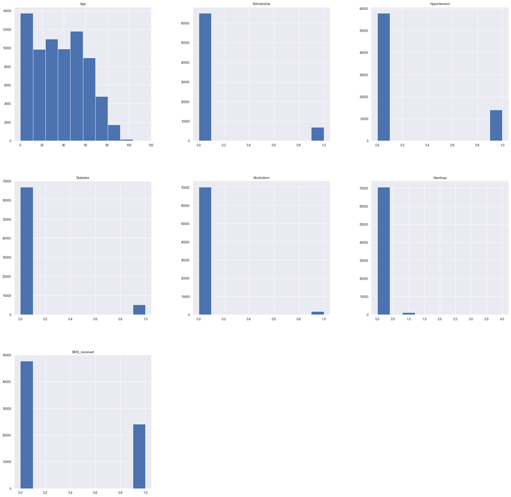

```python
df.hist(figsize=(25,25));
```

- The majority of patients are under the age of 65, most of them have no chronic diseases, and almost no alcoholics or people with disabilities.
- Only a small number have a scholarship, and about a third of the patients receive SMS.

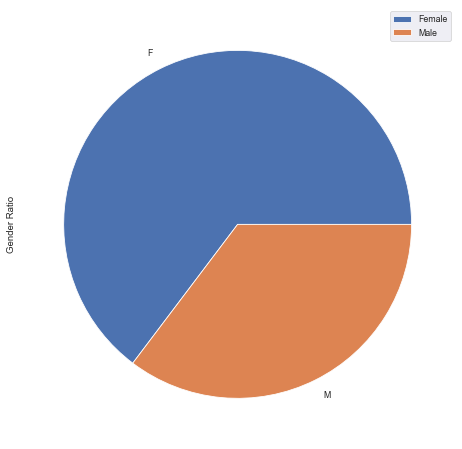

```python
df['Gender'].value_counts().plot(kind='pie', label= 'Gender Ratio', figsize= (8,8))
plt.legend(labels = ['Female', 'Male']);
```

The number of female patients is greater than the number of male patients.

```python
# Deviding the data into two groups by creating two masks to easly select them
show = df.No_show == 'Yes'
no_show = df.No_show == 'No'
```

```python
df[show].count(),df[no_show].count()
```

```
(Gender           17663
 Age              17663
 Neighbourhood    17663
 Scholarship      17663
 Hypertension     17663
 Diabetes         17663
 Alcoholism       17663
 Handcap          17663
 SMS_received     17663
 No_show          17663
 dtype: int64,
 Gender           54153
 Age              54153
 Neighbourhood    54153
 Scholarship      54153
 Hypertension     54153
 Diabetes         54153
 Alcoholism       54153
 Handcap          54153
 SMS_received     54153
 No_show          54153
 dtype: int64)
```

```python
# Displaying the mean for every variable, to cross-examine them according to showing-up status.
df[show].mean(),df[no_show].mean()
```

```
(Age             34.376267
 Scholarship      0.108419
 Hypertension     0.170922
 Diabetes         0.065108
 Alcoholism       0.029440
 Handcap          0.017777
 SMS_received     0.453094
 dtype: float64,
 Age             37.229166
 Scholarship      0.091334
 Hypertension     0.202944
 Diabetes         0.072868
 Alcoholism       0.023600
 Handcap          0.020904
 SMS_received     0.297232
 dtype: float64)
```

The mean age of patients who showed up is 34 and about 45% of them received SMS.The mean age of patients who didn't show up is 37 and about 30% of them received SMS.

```python
# making a function to plot a histogram for each group against 1 variable
def hist_1d(df, col_name, title= None, xlabel= None, ylabel=None):
    plt.figure(figsize= (15,6))
    df[col_name][no_show].hist(alpha=0.7, label= 'No show');
    df[col_name][show].hist(alpha=0.7, label= 'Show');

    # title and labels
    plt.title(title, fontsize = 20)
    plt.xlabel(xlabel,fontsize = 15)
    plt.ylabel(ylabel, fontsize = 15)

    # legend
    plt.legend();
```

```python
# making a function to plot a bar chart of the proportion of each group against 1 variable
def plot_proportions(df, col_name, width, title= None, xlabel= None, ylabel=None):
    counts = df.groupby(['No_show', col_name]).count()['Age']
    total_counts = df.groupby('No_show').count()['Age']
    show_proportions = counts['Yes'] / total_counts['Yes']
    no_show_proportions = counts['No'] / total_counts['No']
    ind = np.arange(len(no_show_proportions))


    # plot bars
    plt.figure(figsize= (15,6))
    no_show_bars = plt.bar(ind, no_show_proportions, width, alpha=.7, label='No show')
    show_bars = plt.bar(ind + width, show_proportions, width, alpha=.7, label='Show')

    # title and labels
    plt.title(title, fontsize = 20)
    plt.xlabel(xlabel,fontsize = 15)
    plt.ylabel(ylabel, fontsize = 15)
    plt.grid(visible= True);
    locations = ind + width / 2  # xtick locations
    labels = df[col_name].unique()  # xtick labels
    plt.xticks(locations, labels)

    # legend
    plt.legend();
```

### The influence of scholarship on attendance:

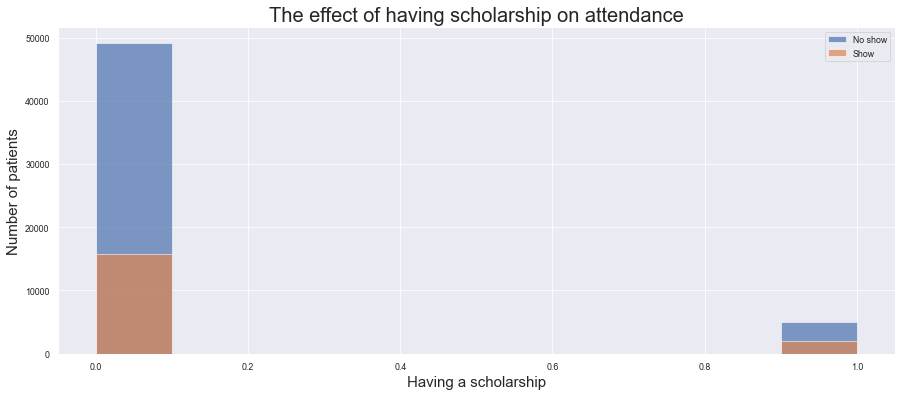

```python
hist_1d(df, 'Scholarship', "The effect of having scholarship on attendance", 'Having a scholarship', 'Number of patients')
```

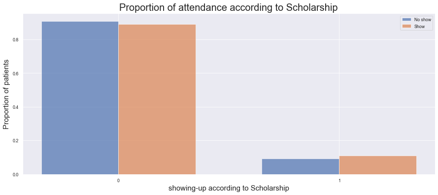

```python
plot_proportions(df, 'Scholarship', 0.35,  'Proportion of attendance according to Scholarship', 'showing-up according to Scholarship', 'Proportion of patients')
```

Having a scholarship has no clear effect on attendance.

### The influence of receiving SMS on attendance:

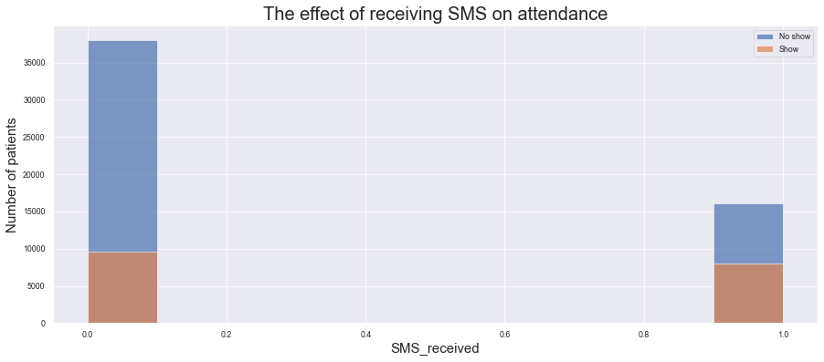

```python
hist_1d(df, 'SMS_received', "The effect of receiving SMS on attendance", 'SMS_received', 'Number of patients')
```

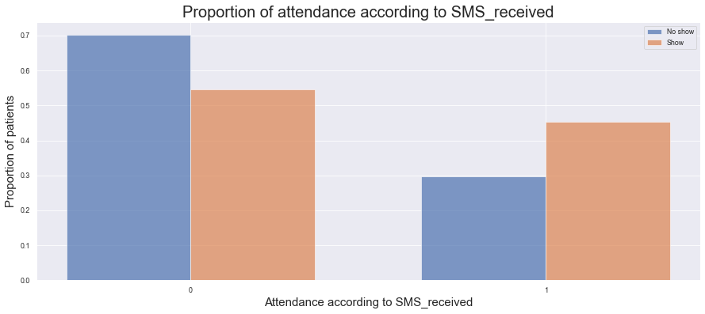

```python
plot_proportions(df, 'SMS_received', 0.35,  'Proportion of attendance according to SMS_received', 'Attendance according to SMS_received', 'Proportion of patients')
```

Proportion of patients who received SMS and didn't show-up are significantlly less than patients who haven't received SMS and didn't show-up.

Let's see that in numbers...

```python
sms_counts = df.groupby(['No_show', 'SMS_received']).count()['Age']
total_sms_counts = df.groupby('No_show').count()['Age']
sms_show_proportions = sms_counts['Yes'] / total_sms_counts['Yes']
sms_no_show_proportions = sms_counts['No'] / total_sms_counts['No']
sms_show_proportions, sms_no_show_proportions
```

```
(SMS_received
 0    0.546906
 1    0.453094
 Name: Age, dtype: float64,
 SMS_received
 0    0.702768
 1    0.297232
 Name: Age, dtype: float64)
```

### The influence of Age on attendance:

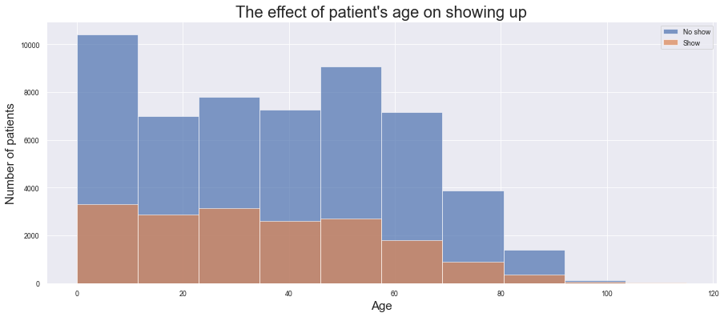

```python
hist_1d(df, 'Age', "The effect of patient's age on showing up", 'Age', 'Number of patients')
```

Patients aged 0–11 have the highest number of shows and no-shows. However, when it comes to ages 11–22, show numbres slightly decrease and no-show numbres drop significantly, which makes it the highest ratio of patients showing. On the other hand, patients over 65 have the lowest number of shows in our samble.

### The influence of Gender on attendance:

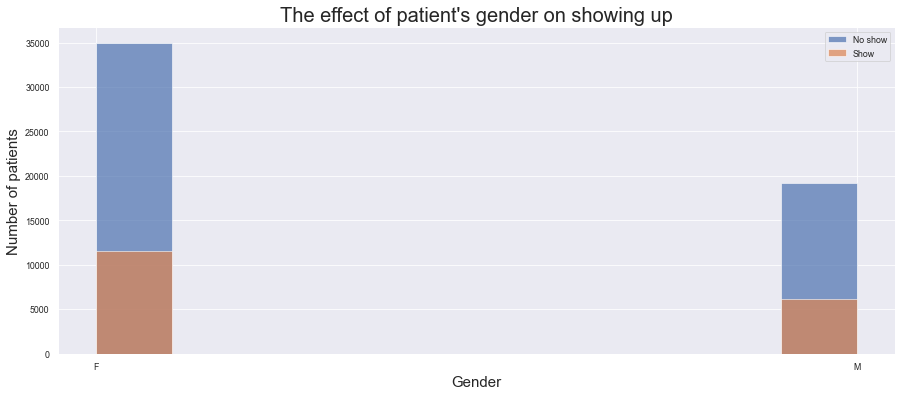

```python
hist_1d(df, 'Gender', "The effect of patient's gender on showing up", 'Gender', 'Number of patients')
```

The numbre of female patients is greater than male patients' in both show and no-show groups.

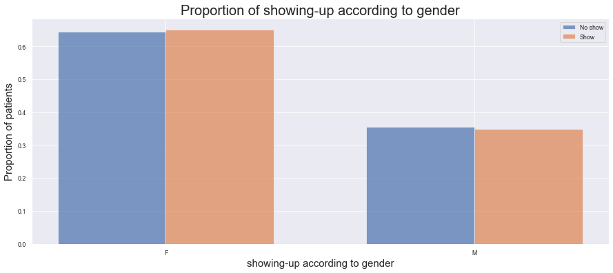

```python
plot_proportions(df, 'Gender', 0.35,  'Proportion of showing-up according to gender', 'showing-up according to gender', 'Proportion of patients')
```

About 65% of patients are females and 35% are male patients, and the proportions of whether the patients show-up or not are the same in both genders.

### Does Age and Gender affect attendance together?

```python
# making a function to plot a bar chart for each group against 2 variables
def bar_2d(df, x_col_name, y_col_name, title= None, xlabel= None, ylabel=None):
    plt.figure(figsize= (15,6))
    df[no_show].groupby(x_col_name)[y_col_name].mean().plot(kind='bar', color='blue', alpha=.6, label= 'No show');
    df[show].groupby(x_col_name)[y_col_name].mean().plot(kind='bar', color='orange', alpha=.6, label= 'show');

    plt.title(title, fontsize = 20)
    plt.xlabel(xlabel,fontsize = 15)
    plt.ylabel(ylabel, fontsize = 15)
    plt.legend();
    plt.grid(visible=True);
```

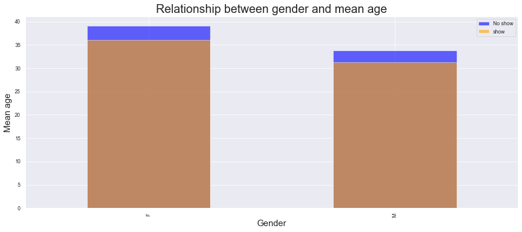

```python
bar_2d(df, 'Gender', 'Age',  'Relationship between gender and mean age', 'Gender', 'Mean age')
```

Mean age of female patients is between 35-40 and for male patients it is between 30-35, but it has no correlation with showing-up.

### The influence of Chronic diseases on attendance:

Becuase of the small number of patiets having chronic diseases we will only explor the proportion of it.

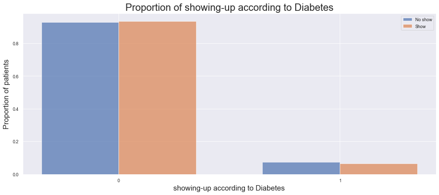

```python
plot_proportions(df, 'Diabetes', 0.35,  'Proportion of showing-up according to Diabetes', 'showing-up according to Diabetes', 'Proportion of patients')
```

Being diabetic has no clear effect on patients showing-up.

[figure not shown]

```python
plot_proportions(df, 'Hypertension', 0.35,  'Proportion of showing-up according to Hypertension', 'showing-up according to Hypertension', 'Proportion of patients')
```

### Does Chronic diseases and Age affect attendance together?

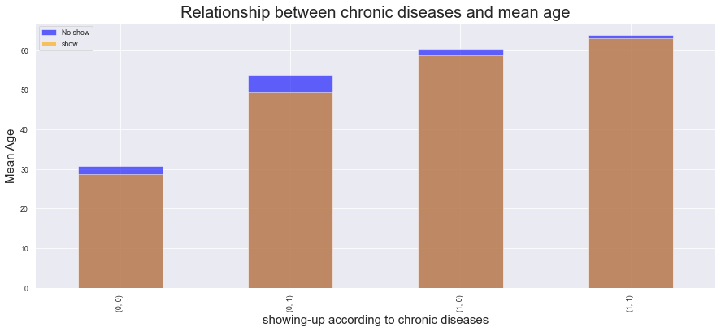

```python
bar_2d(df, ['Hypertension', 'Diabetes'], 'Age', 'Relationship between chronic diseases and mean age', 'showing-up according to chronic diseases', 'Mean Age')
```

Mean age of patients with no chronic diseases are less than patients with chronic diseases, which means that age has strong correlation with chronic diseases but the two of them has no influence on attendance.

### The influence of Neighbourhood on attendance:

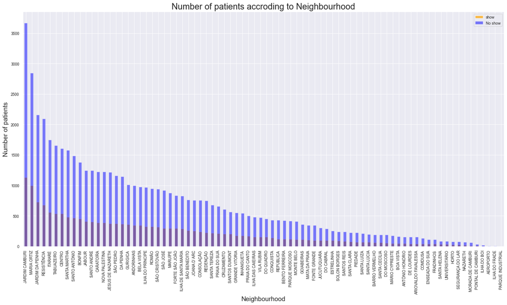

```python
x = df[show]['Neighbourhood'].value_counts()
y = df[no_show]['Neighbourhood'].value_counts()

plt.figure(figsize= (20,10));
x.plot(kind='bar',color='orange', alpha=0.7, label= 'show')
y.plot(kind='bar',color='blue', alpha=0.5, label= 'No show')
plt.legend();
plt.title('Number of patients accroding to Neighbourhood', fontsize = 20)
plt.xlabel('Neighbourhood',fontsize = 15)
plt.ylabel('Number of patients', fontsize = 15);
```

### Does Neighbourhood and Age affect attendance together?

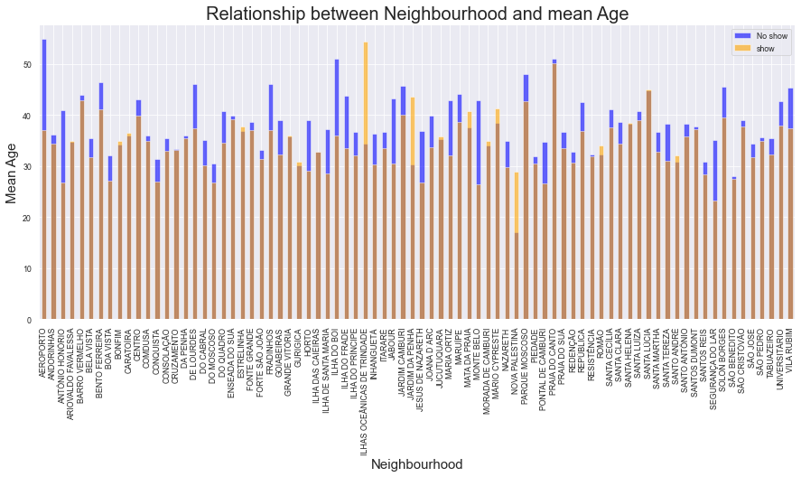

```python
bar_2d(df, 'Neighbourhood', 'Age', 'Relationship between Neighbourhood and mean Age', 'Neighbourhood', 'Mean Age')
```

Here we see that the mean age for the patients diffires from one neighbourhood to another.

## Conclusions

### Limitations

> - There is no clear relationship between patients showing and Gender, Chronic Diseases and having Bolsa Família scholarship.
> - The number of patients suffering from alcoholism is too small to be invstigated.

```python
from subprocess import call
call(['python', '-m', 'nbconvert', 'Investigate_a_Dataset.ipynb'])
```

```
1
```